# Bölmə 14: Tam CAT Simulyasiya Funksiyası

Kompüter Adaptiv Testləşmə (CAT) Tədrisi

CAT Tədrisi

2025-07-12

# 1 Giriş

Bu bölmədə Kompüter Adaptiv Testləşmə (CAT) sisteminin tam simulyasiya funksiyasını yaradacağıq. Bu funksiya əvvəlki bölmələrdə öyrəndiyimiz bütün komponentləri birləşdirərək tam funksional CAT sessiyası simulyasiya edir.

CAT simulyasiyası müxtəlif komponentlərin harmonik birləşməsindən ibarətdir: item seçimi, cavab generasiyası, qabiliyyət qiymətləndirməsi və sonlandırma kriteriyaları. Bu bölmədə həm fərdi həm də kütləvi simulyasiyalar üçün ətraflı həllər təqdim edəcəyik.

## 1.1 CAT Simulyasiyasının Əhəmiyyəti

Tam CAT simulyasiyası tədqiqatçılara və test tərtibçilərinə aşağıdakı imkanları verir:

1. **Sistem Performansının Qiymətləndirilməsi**: Real şəraitdə CAT alqoritmlərinin necə işləyəcəyini anlamaq
2. **Strategiya Müqayisəsi**: Müxtəlif item seçimi və sonlandırma strategiyalarının effektivliyini müqayisə etmək
3. **Parametr Optimizasiyası**: Optimal test parametrlərini müəyyən etmək
4. **Keyfiyyət Nəzarəti**: Test dəqiqliyi və effektivliyini ölçmək

## 1.2 Simulyasiya Komponentləri

CAT simulyasiyası aşağıdakı əsas komponentlərdən ibarətdir:

- **Item Bank**: Test tapşırıqlarının məcmusu
- **Item Selection Algorithm**: Növbəti tapşırığın seçilməsi meyarı
- **Response Generation**: Test alıcısı cavablarının simulyasiyası
- **Ability Estimation**: Qabiliyyət səviyyəsinin qiymətləndirilməsi
- **Termination Criteria**: Testin sonlandırılması kriteriyaları

# 2 Köməkçi Funksiyalar

Tam CAT simulyasiyası üçün əvvəl bir neçə köməkçi funksiya lazımdır:

## 2.1 Item Seçimi Funksiyası

```r
# Item seçimi funksiyası - Maximum Fisher Information meyarı
select_next_item <- function(current_theta, item_bank, administered_items = c()) {

    cat("=== ITEM SEÇİMİ ALGORİTMİ ===\n")
    cat("Current theta:", round(current_theta, 3), "\n")
    cat("Administered items sayı:", length(administered_items), "\n")

    # Mövcud items
    available_items <- setdiff(1:nrow(item_bank), administered_items)

    if (length(available_items) == 0) {
        cat("XƏBƏRDARLIQ: Heç bir item qalmayıb!\n")
        return(NULL)
    }

    cat("Available items sayı:", length(available_items), "\n")

    # Hər available item üçün Fisher Information hesabla
    information_values <- numeric(length(available_items))

    for (i in 1:length(available_items)) {
        item_idx <- available_items[i]

        a <- item_bank$a[item_idx]
        b <- item_bank$b[item_idx]
        c <- item_bank$c[item_idx]

        # 3PL model üçün Fisher Information
        P <- c + (1 - c) * plogis(a * (current_theta - b))
        Q <- 1 - P
        P_prime <- a * (1 - c) * exp(-a * (current_theta - b)) /
                   (1 + exp(-a * (current_theta - b)))^2

        # P və Q-nun sıfıra çox yaxın olmasının qarşısını almaq
        P <- pmax(0.0001, pmin(0.9999, P))
        Q <- 1 - P

        information_values[i] <- (P_prime^2) / (P * Q)
    }

    # Ən yüksək information-a malik itemi seç
    best_item_position <- which.max(information_values)
    selected_item <- available_items[best_item_position]

    cat("Seçilmiş item:", selected_item, "\n")
    cat("Fisher Information:", round(information_values[best_item_position], 3), "\n")
    cat("Item parametrləri: a =", round(item_bank$a[selected_item], 2),
        ", b =", round(item_bank$b[selected_item], 2),
        ", c =", round(item_bank$c[selected_item], 2), "\n\n")

    return(list(
        item_index = selected_item,
        information = information_values[best_item_position],
        available_count = length(available_items)
    ))
}

# Test item bank yaradaq
set.seed(123)
test_item_bank <- data.frame(
    a = runif(20, 0.8, 2.5),
    b = rnorm(20, 0, 1.2),
    c = runif(20, 0.1, 0.25)
)

cat("=== ITEM SEÇİMİ TESTİ ===\n")
```

```
## === ITEM SEÇİMİ TESTİ ===
```

```r
# Müxtəlif theta dəyərləri üçün item seçimi
test_thetas <- c(-1, 0, 1)
for(theta in test_thetas) {
    cat("Theta =", theta, " üçün:\n")
    selection <- select_next_item(theta, test_item_bank, c())
    cat("---\n")
}
```

```
## Theta = -1  üçün:
## === ITEM SEÇİMİ ALGORİTMİ ===
## Current theta: -1
## Administered items sayı: 0
## Available items sayı: 20
## Seçilmiş item: 11
## Fisher Information: 0.933
## Item parametrləri: a = 2.43 , b = -1.28 , c = 0.21
##
## ---
## Theta = 0  üçün:
## === ITEM SEÇİMİ ALGORİTMİ ===
## Current theta: 0
## Administered items sayı: 0
## Available items sayı: 20
## Seçilmiş item: 4
## Fisher Information: 0.932
## Item parametrləri: a = 2.3 , b = 0.13 , c = 0.14
##
## ---
## Theta = 1  üçün:
## === ITEM SEÇİMİ ALGORİTMİ ===
## Current theta: 1
## Administered items sayı: 0
## Available items sayı: 20
## Seçilmiş item: 2
## Fisher Information: 0.692
## Item parametrləri: a = 2.14 , b = 0.43 , c = 0.11
##
## ---
```

## 2.2 Qabiliyyət Qiymətləndirmə Funksiyası (EAP)

```r
# Expected A Posteriori (EAP) qiymətləndirmə
estimate_ability_eap <- function(administered_items, responses, item_bank,
                                prior_mean = 0, prior_sd = 1,
                                theta_range = seq(-4, 4, 0.1)) {

    cat("=== QABİLİYYƏT QİYMƏTLƏNDİRMƏ (EAP) ===\n")
    cat("Administered items:", length(administered_items), "\n")
    cat("Responses:", paste(responses, collapse = ", "), "\n")

    if (length(administered_items) == 0 || length(responses) == 0) {
        cat("Boş data - prior qaytarılır\n")
        return(list(theta = prior_mean, se = prior_sd))
    }

    # Theta grid üzərində hesablama
    likelihood <- numeric(length(theta_range))

    for (j in 1:length(theta_range)) {
        theta <- theta_range[j]
        log_likelihood <- 0

        for (i in 1:length(administered_items)) {
            item_idx <- administered_items[i]
            response <- responses[i]

            a <- item_bank$a[item_idx]
            b <- item_bank$b[item_idx]
            c <- item_bank$c[item_idx]

            # 3PL model ehtimalı
            P <- c + (1 - c) * plogis(a * (theta - b))
            P <- pmax(0.0001, pmin(0.9999, P))  # Numerical stability

            if (response == 1) {
                log_likelihood <- log_likelihood + log(P)
            } else {
                log_likelihood <- log_likelihood + log(1 - P)
            }
        }

        likelihood[j] <- exp(log_likelihood)
    }

    # Prior distribution (normal)
    prior <- dnorm(theta_range, prior_mean, prior_sd)

    # Posterior distribution
    posterior <- likelihood * prior

    # Normalization
    if (sum(posterior) > 0) {
        posterior <- posterior / sum(posterior)
    } else {
        # Əgər posterior sıfırdırsa, priora qayıt
        posterior <- prior / sum(prior)
        cat("XƏBƏRDARLIQ: Posterior sıfır, priora qayıdıldı\n")
    }

    # EAP estimate
    theta_eap <- sum(theta_range * posterior)

    # Posterior variance və standard error
    variance_post <- sum((theta_range - theta_eap)^2 * posterior)
    se_eap <- sqrt(variance_post)

    cat("EAP theta:", round(theta_eap, 3), "\n")
    cat("Posterior SE:", round(se_eap, 3), "\n\n")

    return(list(
        theta = theta_eap,
        se = se_eap,
        posterior = posterior,
        theta_range = theta_range
    ))
}

# EAP funksiya testi
cat("=== EAP FUNKSİYA TESTİ ===\n")
```

```
## === EAP FUNKSİYA TESTİ ===
```

```r
sample_items <- c(1, 5, 10)
sample_responses <- c(1, 0, 1)

eap_result <- estimate_ability_eap(sample_items, sample_responses, test_item_bank)
```

```
## === QABİLİYYƏT QİYMƏTLƏNDİRMƏ (EAP) ===
## Administered items: 3
## Responses: 1, 0, 1
## EAP theta: -0.555
## Posterior SE: 0.722
```

## 2.3 Sonlandırma Kriteriyaları Funksiyası

```r
# Sonlandırma kriteriyalarını yoxlama
check_termination <- function(current_step, theta_se, min_items = 5, max_items = 30, se_threshold = 0.3) {

    cat("=== SONLANDIRMA KRİTERİYALARI YOXLAMASI ===\n")
    cat("Current step:", current_step, "\n")
    cat("Current SE:", round(theta_se, 3), "\n")
    cat("Min items:", min_items, ", Max items:", max_items, ", SE threshold:", se_threshold, "\n")

    # Minimum item sayına çatmayıbsa
    if (current_step < min_items) {
        reason <- paste("Minimum item sayına çatılmayıb:", current_step, "/", min_items)
        cat("Qərar: DAVAM (", reason, ")\n\n")
        return(list(terminate = FALSE, reason = reason))
    }

    # Maksimum item sayına çatıbsa
    if (current_step >= max_items) {
        reason <- paste("Maksimum item sayına çatıldı:", current_step, "/", max_items)
        cat("Qərar: SONLANDIR (", reason, ")\n\n")
        return(list(terminate = TRUE, reason = reason))
    }

    # SE threshold-a çatıbsa
    if (!is.na(theta_se) && theta_se <= se_threshold) {
        reason <- paste("Tələb olunan dəqiqliyə çatıldı: SE =", round(theta_se, 3), "≤", se_threshold)
        cat("Qərar: SONLANDIR (", reason, ")\n\n")
        return(list(terminate = TRUE, reason = reason))
    }

    # Davam etməli
    reason <- paste("Davam edir: SE =", round(theta_se, 3), "> threshold =", se_threshold)
    cat("Qərar: DAVAM (", reason, ")\n\n")
    return(list(terminate = FALSE, reason = reason))
}

# Sonlandırma funksiya testi
cat("=== SONLANDIRMA FUNKSİYA TESTİ ===\n")
```

```
## === SONLANDIRMA FUNKSİYA TESTİ ===
```

```r
test_scenarios <- list(
    list(step = 3, se = 0.4, desc = "Az item, yüksək SE"),
    list(step = 8, se = 0.25, desc = "Kifayət item, aşağı SE"),
    list(step = 30, se = 0.5, desc = "Max item, yüksək SE")
)

for(i in 1:length(test_scenarios)) {
    scenario <- test_scenarios[[i]]
    cat("Ssenari", i, ":", scenario$desc, "\n")
    result <- check_termination(scenario$step, scenario$se)
    cat("---\n")
}
```

```
## Ssenari 1 : Az item, yüksək SE
## === SONLANDIRMA KRİTERİYALARI YOXLAMASI ===
## Current step: 3
## Current SE: 0.4
## Min items: 5 , Max items: 30 , SE threshold: 0.3
## Qərar: DAVAM ( Minimum item sayına çatılmayıb: 3 / 5 )
##
## ---
## Ssenari 2 : Kifayət item, aşağı SE
## === SONLANDIRMA KRİTERİYALARI YOXLAMASI ===
## Current step: 8
## Current SE: 0.25
## Min items: 5 , Max items: 30 , SE threshold: 0.3
## Qərar: SONLANDIR ( Tələb olunan dəqiqliyə çatıldı: SE = 0.25 ≤ 0.3 )
##
## ---
## Ssenari 3 : Max item, yüksək SE
## === SONLANDIRMA KRİTERİYALARI YOXLAMASI ===
## Current step: 30
## Current SE: 0.5
## Min items: 5 , Max items: 30 , SE threshold: 0.3
## Qərar: SONLANDIR ( Maksimum item sayına çatıldı: 30 / 30 )
##
## ---
```

## 2.4 Cavab Generasiya Funksiyası

```r
# Əvvəlki bölmədən cavab generasiya funksiyası
generate_response <- function(true_theta, item_params, include_error = TRUE) {
    a <- item_params$a
    b <- item_params$b
    c <- item_params$c

    # 3PL modelə əsasən doğru cavab ehtimalı
    prob_correct <- c + (1 - c) * plogis(a * (true_theta - b))

    # Əlavə xəta mənbələri
    if (include_error) {
        error_factor <- rnorm(1, 0, 0.05)
        prob_correct <- pmax(0, pmin(1, prob_correct + error_factor))
    }

    # Bernoulli sınağı
    response <- rbinom(1, 1, prob_correct)

    return(list(
        response = response,
        prob_correct = prob_correct,
        item_difficulty = b,
        discrimination = a
    ))
}

cat("=== CAVAB GENERASİYA FUNKSİYA TESTİ ===\n")
```

```
## === CAVAB GENERASİYA FUNKSİYA TESTİ ===
```

```r
sample_item <- test_item_bank[1, ]
cat("Item parametrləri: a =", round(sample_item$a, 2),
    ", b =", round(sample_item$b, 2),
    ", c =", round(sample_item$c, 2), "\n")
```

```
## Item parametrləri: a = 1.29 , b = 1.47 , c = 0.2
```

```r
for(theta in c(-1, 0, 1)) {
    test_response <- generate_response(theta, sample_item)
    cat("Theta =", theta, ": Response =", test_response$response,
        ", P(correct) =", round(test_response$prob_correct, 3), "\n")
}
```

```
## Theta = -1 : Response = 0 , P(correct) = 0.197
## Theta = 0 : Response = 0 , P(correct) = 0.345
## Theta = 1 : Response = 0 , P(correct) = 0.591
```

```r
cat("\n")
```

# 3 Ana CAT Simulyasiya Funksiyası

```r
# Tam CAT simulyasiyası
run_cat_simulation <- function(examinee_ability, item_bank,
                              min_items = 5, max_items = 30, se_threshold = 0.3,
                              verbose = TRUE) {

    # Başlanğıc parametrlər
    administered_items <- c()
    responses <- c()
    theta_estimates <- c()
    se_estimates <- c()
    current_theta <- 0  # İlkin qabiliyyət qiymətləndirməsi
    current_se <- 1.0   # İlkin SE

    if (verbose) {
        cat("=== CAT SİMULYASİYA BAŞLADI ===\n")
        cat("Həqiqi θ:", examinee_ability, "\n")
        cat("Parametrlər: min_items =", min_items, ", max_items =", max_items,
            ", SE threshold =", se_threshold, "\n")
        cat("Item bank ölçüsü:", nrow(item_bank), "\n\n")
    }

    for (step in 1:max_items) {

        if (verbose) cat(">>> ADDIM", step, "<<<\n")

        # Tapşırıq seçimi
        if (step == 1) {
            # İlk tapşırıq - orta çətinlik
            if (verbose) cat("İlk item seçimi (orta çətinlik)\n")
            available_items <- 1:nrow(item_bank)
            difficulty_diff <- abs(item_bank$b - 0)
            selected_item <- available_items[which.min(difficulty_diff)]

            if (verbose) {
                cat("Seçilmiş item:", selected_item,
                    "(b =", round(item_bank$b[selected_item], 2), ")\n")
            }
        } else {
            # Sonrakı tapşırıqlar - Maximum Fisher Information
            if (verbose) cat("Fisher Information əsaslı item seçimi\n")
            item_selection <- select_next_item(current_theta, item_bank, administered_items)
            if (is.null(item_selection)) {
                if (verbose) cat("Heç bir item qalmadı - simulyasiya dayandırıldı!\n")
                break
            }
            selected_item <- item_selection$item_index
        }

        administered_items <- c(administered_items, selected_item)

        # Cavab generasiyası
        response_result <- generate_response(examinee_ability, item_bank[selected_item, ])
        responses <- c(responses, response_result$response)

        if (verbose) {
            cat("Response generasiyası:\n")
            cat("  Cavab:", response_result$response,
                "(P =", round(response_result$prob_correct, 3), ")\n")
        }

        # Qabiliyyət qiymətləndirmə (2-ci tapşırıqdan etibarən)
        if (step >= 2) {
            if (verbose) cat("Qabiliyyət qiymətləndirməsi:\n")
            ability_est <- estimate_ability_eap(administered_items, responses, item_bank)
            current_theta <- ability_est$theta
            current_se <- ability_est$se

            theta_estimates <- c(theta_estimates, current_theta)
            se_estimates <- c(se_estimates, current_se)

            if (verbose) {
                cat("  θ̂ =", round(current_theta, 3), ", SE =", round(current_se, 3), "\n")
                cat("  Mütləq xəta:", round(abs(current_theta - examinee_ability), 3), "\n")
            }

            # Sonlandırma kriteriyalarını yoxla
            termination <- check_termination(step, current_se, min_items, max_items, se_threshold)

            if (termination$terminate) {
                if (verbose) cat(">>> TEST SONLANDI <<<\n")
                if (verbose) cat("Səbəb:", termination$reason, "\n")
                break
            }
        }

        if (verbose) cat("---\n")
    }

    # Final qiymətləndirmə
    if (verbose) cat("\nFinal qiymətləndirmə hesablanır...\n")
    final_ability <- estimate_ability_eap(administered_items, responses, item_bank)

    return(list(
        administered_items = administered_items,
        responses = responses,
        theta_estimates = theta_estimates,
        se_estimates = se_estimates,
        final_theta = final_ability$theta,
        final_se = final_ability$se,
        items_count = length(administered_items),
        accuracy = mean(responses),
        true_theta = examinee_ability,
        estimation_error = abs(final_ability$theta - examinee_ability)
    ))
}

# İndi item bank və examinees yaradaq
set.seed(456)
item_bank <- data.frame(
    a = runif(50, 0.8, 2.5),
    b = rnorm(50, 0, 1.2),
    c = runif(50, 0.1, 0.25)
)

set.seed(789)
examinees <- data.frame(
    id = 1:3,
    true_theta = c(-1.0, 0.0, 1.5)
)

cat("=== ITEM BANK VƏ EXAMİNEES MƏLUMATLARI ===\n")
```

```
## === ITEM BANK VƏ EXAMİNEES MƏLUMATLARI ===
```

```r
cat("Item sayı:", nrow(item_bank), "\n")
```

```
## Item sayı: 50
```

```r
cat("a parametri aralığı:", round(range(item_bank$a), 2), "\n")
```

```
## a parametri aralığı: 0.87 2.48
```

```r
cat("b parametri aralığı:", round(range(item_bank$b), 2), "\n")
```

```
## b parametri aralığı: -2.71 2.49
```

```r
cat("c parametri aralığı:", round(range(item_bank$c), 2), "\n")
```

```
## c parametri aralığı: 0.11 0.25
```

```r
cat("Test alıcı sayı:", nrow(examinees), "\n")
```

```
## Test alıcı sayı: 3
```

```r
cat("True theta aralığı:", range(examinees$true_theta), "\n\n")
```

```
## True theta aralığı: -1 1.5
```

```r
# Bir test alıcısı üçün ətraflı simulyasiya
cat("=== BİR TEST ALICISININ ƏTRAFLİ SİMULYASİYASI ===\n")
```

```
## === BİR TEST ALICISININ ƏTRAFLİ SİMULYASİYASI ===
```

```r
single_result <- run_cat_simulation(examinees$true_theta[1], item_bank, verbose = TRUE)
```

```
## === CAT SİMULYASİYA BAŞLADI ===
## Həqiqi θ: -1
## Parametrlər: min_items = 5 , max_items = 30 , SE threshold = 0.3
## Item bank ölçüsü: 50
##
## >>> ADDIM 1 <<<
## İlk item seçimi (orta çətinlik)
## Seçilmiş item: 50 (b = -0.02 )
## Response generasiyası:
##   Cavab: 0 (P = 0.284 )
## ---
## >>> ADDIM 2 <<<
## Fisher Information əsaslı item seçimi
## === ITEM SEÇİMİ ALGORİTMİ ===
## Current theta: 0
## Administered items sayı: 1
## Available items sayı: 49
## Seçilmiş item: 27
## Fisher Information: 0.957
## Item parametrləri: a = 2.42 , b = -0.31 , c = 0.18
##
## Response generasiyası:
##   Cavab: 0 (P = 0.324 )
## Qabiliyyət qiymətləndirməsi:
## === QABİLİYYƏT QİYMƏTLƏNDİRMƏ (EAP) ===
## Administered items: 2
## Responses: 0, 0
## EAP theta: -0.982
## Posterior SE: 0.667
##
##   θ̂ = -0.982 , SE = 0.667
##   Mütləq xəta: 0.018
## === SONLANDIRMA KRİTERİYALARI YOXLAMASI ===
## Current step: 2
## Current SE: 0.667
## Min items: 5 , Max items: 30 , SE threshold: 0.3
## Qərar: DAVAM ( Minimum item sayına çatılmayıb: 2 / 5 )
##
## ---
## >>> ADDIM 3 <<<
```

[output cut: 776 more lines]

```
## === SONLANDIRMA KRİTERİYALARI YOXLAMASI ===
## Current step: 30
## Current SE: 0.307
## Min items: 5 , Max items: 30 , SE threshold: 0.3
## Qərar: SONLANDIR ( Maksimum item sayına çatıldı: 30 / 30 )
##
## >>> TEST SONLANDI <<<
## Səbəb: Maksimum item sayına çatıldı: 30 / 30
##
## Final qiymətləndirmə hesablanır...
## === QABİLİYYƏT QİYMƏTLƏNDİRMƏ (EAP) ===
## Administered items: 30
## Responses: 0, 0, 1, 1, 0, 1, 0, 1, 0, 0, 0, 1, 0, 0, 1, 1, 0, 1, 0, 1, 0, 1, 0, 1, 1, 0, 0, 0, 1, 0
## EAP theta: -0.958
## Posterior SE: 0.307
```

## 3.1 Simulyasiya Nəticələrinin Təhlili

```r
cat("\n=== SİMULYASİYA NƏTİCƏLƏRİNİN TƏHLİLİ ===\n")
```

```
##
## === SİMULYASİYA NƏTİCƏLƏRİNİN TƏHLİLİ ===
```

```r
cat("Həqiqi qabiliyyət:", round(examinees$true_theta[1], 3), "\n")
```

```
## Həqiqi qabiliyyət: -1
```

```r
cat("Qiymətləndirilmiş qabiliyyət:", round(single_result$final_theta, 3), "\n")
```

```
## Qiymətləndirilmiş qabiliyyət: -0.958
```

```r
cat("Standart xəta:", round(single_result$final_se, 3), "\n")
```

```
## Standart xəta: 0.307
```

```r
cat("İstifadə edilən tapşırıq sayı:", single_result$items_count, "\n")
```

```
## İstifadə edilən tapşırıq sayı: 30
```

```r
cat("Doğru cavab nisbəti:", round(single_result$accuracy, 3), "\n")
```

```
## Doğru cavab nisbəti: 0.433
```

```r
cat("Qiymətləndirmə xətası:", round(single_result$estimation_error, 3), "\n")
```

```
## Qiymətləndirmə xətası: 0.042
```

```r
# İstifadə edilən itemlərin təhlili
used_items <- single_result$administered_items
used_item_params <- item_bank[used_items, ]

cat("\nİstifadə edilən itemlərin statistikaları:\n")
```

```
##
## İstifadə edilən itemlərin statistikaları:
```

```r
cat("a parametri - Orta:", round(mean(used_item_params$a), 3),
    ", SD:", round(sd(used_item_params$a), 3), "\n")
```

```
## a parametri - Orta: 1.654 , SD: 0.509
```

```r
cat("b parametri - Orta:", round(mean(used_item_params$b), 3),
    ", SD:", round(sd(used_item_params$b), 3), "\n")
```

```
## b parametri - Orta: -0.579 , SD: 0.665
```

```r
cat("c parametri - Orta:", round(mean(used_item_params$c), 3),
    ", SD:", round(sd(used_item_params$c), 3), "\n")
```

```
## c parametri - Orta: 0.186 , SD: 0.042
```

```
##
## Konvergens məlumatları:
##    Step Theta_Estimate        SE True_Theta
## 1     2     -0.9822297 0.6667709         -1
## 2     3     -0.7807405 0.5912671         -1
## 3     4     -0.6363110 0.5200467         -1
## 4     5     -0.8411937 0.4836383         -1
## 5     6     -0.7049355 0.4465722         -1
## 6     7     -0.8290628 0.4293409         -1
## 7     8     -0.7615462 0.4024098         -1
## 8     9     -0.8438554 0.3862031         -1
## 9    10     -0.9029060 0.3782096         -1
## 10   11     -0.9617469 0.3769920         -1
## 11   12     -0.9343482 0.3626911         -1
## 12   13     -0.9721936 0.3586160         -1
```

[output cut: 17 more lines]

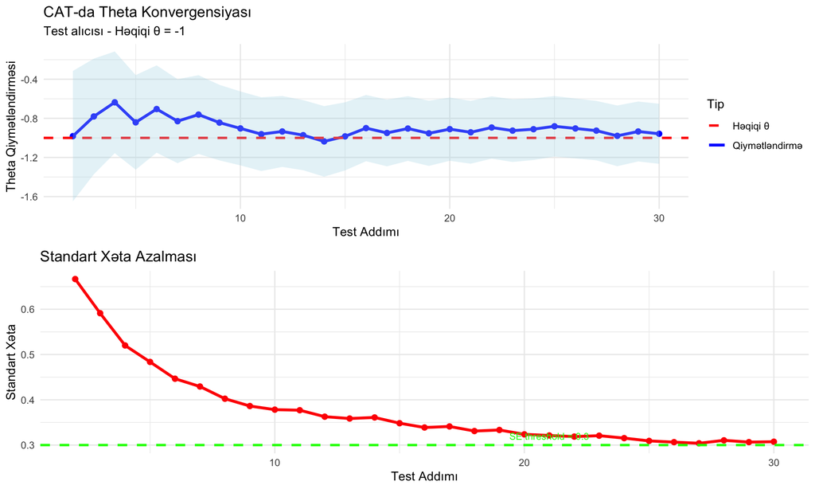

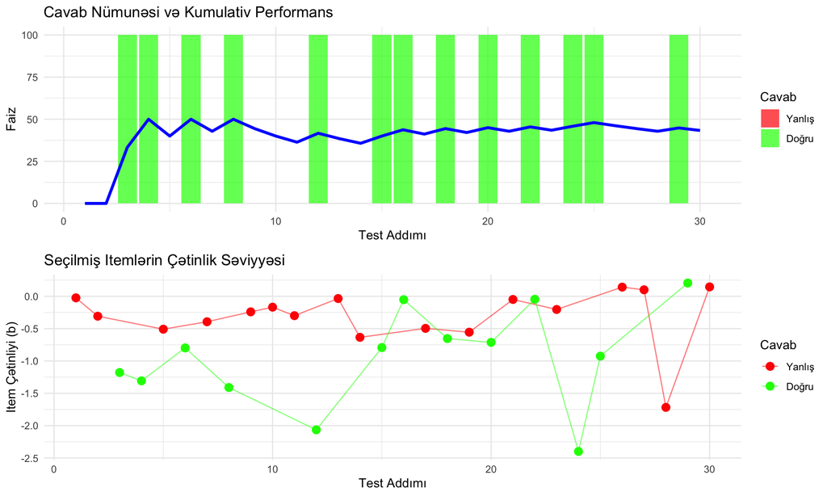

```r
# Konvergens qrafiki yaratmaq
if (length(single_result$theta_estimates) > 0) {

    convergence_data <- data.frame(
        Step = 2:(length(single_result$theta_estimates) + 1),
        Theta_Estimate = single_result$theta_estimates,
        SE = single_result$se_estimates,
        True_Theta = single_result$true_theta
    )

    cat("\nKonvergens məlumatları:\n")
    print(convergence_data)

    # Theta konvergensi qrafiki
    p1 <- ggplot(convergence_data, aes(x = Step)) +
        geom_line(aes(y = Theta_Estimate, color = "Qiymətləndirmə"), size = 1.2) +
        geom_point(aes(y = Theta_Estimate), color = "blue", size = 2) +
        geom_hline(aes(yintercept = True_Theta, color = "Həqiqi θ"),
                   linetype = "dashed", size = 1) +
        geom_ribbon(aes(ymin = Theta_Estimate - SE, ymax = Theta_Estimate + SE),
                    alpha = 0.3, fill = "lightblue") +
        labs(title = "CAT-da Theta Konvergensiyası",
             subtitle = paste("Test alıcısı - Həqiqi θ =", single_result$true_theta),
             x = "Test Addımı", y = "Theta Qiymətləndirməsi",
             color = "Tip") +
        theme_minimal() +
        scale_color_manual(values = c("Qiymətləndirmə" = "blue", "Həqiqi θ" = "red"))

    # SE azalması qrafiki
    p2 <- ggplot(convergence_data, aes(x = Step, y = SE)) +
        geom_line(size = 1.2, color = "red") +
        geom_point(size = 2, color = "red") +
        geom_hline(yintercept = 0.3, linetype = "dashed", color = "green", size = 1) +
        labs(title = "Standart Xəta Azalması",
             x = "Test Addımı", y = "Standart Xəta") +
        theme_minimal() +
        annotate("text", x = max(convergence_data$Step) * 0.7, y = 0.32,
                 label = "SE threshold = 0.3", color = "green", size = 3)

    grid.arrange(p1, p2, ncol = 1)

    # Response pattern analizi
    response_data <- data.frame(
        Step = 1:length(single_result$responses),
        Response = single_result$responses,
        Item_ID = single_result$administered_items
    )

    response_data$Item_Difficulty <- item_bank$b[response_data$Item_ID]
    response_data$Cumulative_Score <- cumsum(response_data$Response)
    response_data$Cumulative_Percent <- response_data$Cumulative_Score / response_data$Step * 100

    # Response pattern qrafiki
    p3 <- ggplot(response_data, aes(x = Step)) +
        geom_col(aes(y = Response * 100, fill = as.factor(Response)), alpha = 0.7) +
        geom_line(aes(y = Cumulative_Percent), color = "blue", size = 1.2) +
        labs(title = "Cavab Nümunəsi və Kumulativ Performans",
             x = "Test Addımı", y = "Faiz",
             fill = "Cavab") +
        theme_minimal() +
        scale_fill_manual(values = c("0" = "red", "1" = "green"),
                         labels = c("0" = "Yanlış", "1" = "Doğru"))

    # Item çətinliyi vs Addım
    p4 <- ggplot(response_data, aes(x = Step, y = Item_Difficulty, color = as.factor(Response))) +
        geom_point(size = 3) +
        geom_line(alpha = 0.5) +
        labs(title = "Seçilmiş Itemlərin Çətinlik Səviyyəsi",
             x = "Test Addımı", y = "Item Çətinliyi (b)",
             color = "Cavab") +
        theme_minimal() +
        scale_color_manual(values = c("0" = "red", "1" = "green"),
                          labels = c("0" = "Yanlış", "1" = "Doğru"))

    grid.arrange(p3, p4, ncol = 1)
}
```

# 4 Çoxlu Test Alıcısı Simulyasiyası

```r
# Çoxlu test alıcısı üçün simulyasiya
run_multiple_simulations <- function(examinees_df, item_bank,
                                    min_items = 5, max_items = 30, se_threshold = 0.3) {

    cat("=== ÇOXLU TEST ALICISI SİMULYASİYASI ===\n")
    cat("Test alıcı sayı:", nrow(examinees_df), "\n")
    cat("Item bank ölçüsü:", nrow(item_bank), "\n\n")

    results_list <- list()

    for (i in 1:nrow(examinees_df)) {
        cat("Test alıcısı", i, "/", nrow(examinees_df),
            "(θ =", examinees_df$true_theta[i], ") işlənir...\n")

        # Simulyasiya aparma (verbose = FALSE)
        result <- run_cat_simulation(
            examinee_ability = examinees_df$true_theta[i],
            item_bank = item_bank,
            min_items = min_items,
            max_items = max_items,
            se_threshold = se_threshold,
            verbose = FALSE
        )

        # Examinee ID əlavə etmə
        result$examinee_id <- examinees_df$id[i]
        results_list[[i]] <- result

        cat("  Tamamlandı: Items =", result$items_count,
            ", Final θ =", round(result$final_theta, 3),
            ", SE =", round(result$final_se, 3), "\n")
    }

    cat("\nBütün simulyasiyalar tamamlandı!\n\n")
    return(results_list)
}

# Çoxlu test alıcısı simulyasiyası
multiple_results <- run_multiple_simulations(examinees, item_bank)
```

```
## === ÇOXLU TEST ALICISI SİMULYASİYASI ===
## Test alıcı sayı: 3
## Item bank ölçüsü: 50
##
## Test alıcısı 1 / 3 (θ = -1 ) işlənir...
## === ITEM SEÇİMİ ALGORİTMİ ===
## Current theta: 0
## Administered items sayı: 1
## Available items sayı: 49
## Seçilmiş item: 27
## Fisher Information: 0.957
## Item parametrləri: a = 2.42 , b = -0.31 , c = 0.18
##
## === QABİLİYYƏT QİYMƏTLƏNDİRMƏ (EAP) ===
## Administered items: 2
## Responses: 0, 0
## EAP theta: -0.982
## Posterior SE: 0.667
##
## === SONLANDIRMA KRİTERİYALARI YOXLAMASI ===
## Current step: 2
## Current SE: 0.667
## Min items: 5 , Max items: 30 , SE threshold: 0.3
## Qərar: DAVAM ( Minimum item sayına çatılmayıb: 2 / 5 )
##
## === ITEM SEÇİMİ ALGORİTMİ ===
## Current theta: -0.982
## Administered items sayı: 2
## Available items sayı: 48
## Seçilmiş item: 37
## Fisher Information: 0.964
## Item parametrləri: a = 2.48 , b = -1.18 , c = 0.24
##
## === QABİLİYYƏT QİYMƏTLƏNDİRMƏ (EAP) ===
## Administered items: 3
## Responses: 0, 0, 0
## EAP theta: -1.427
## Posterior SE: 0.606
##
## === SONLANDIRMA KRİTERİYALARI YOXLAMASI ===
```

[output cut: 1475 more lines]

```
## === SONLANDIRMA KRİTERİYALARI YOXLAMASI ===
## Current step: 30
## Current SE: 0.314
## Min items: 5 , Max items: 30 , SE threshold: 0.3
## Qərar: SONLANDIR ( Maksimum item sayına çatıldı: 30 / 30 )
##
## === QABİLİYYƏT QİYMƏTLƏNDİRMƏ (EAP) ===
## Administered items: 30
## Responses: 1, 1, 1, 0, 1, 0, 1, 1, 1, 1, 0, 1, 0, 1, 1, 1, 1, 1, 1, 1, 1, 1, 0, 1, 1, 1, 0, 1, 1, 0
## EAP theta: 1.131
## Posterior SE: 0.314
##
##   Tamamlandı: Items = 30 , Final θ = 1.131 , SE = 0.314
##
## Bütün simulyasiyalar tamamlandı!
```

```r
# Nəticələri data frame formatına çevirmə
extract_simulation_summary <- function(results_list) {

    summary_data <- data.frame(
        Examinee_ID = sapply(results_list, function(x) x$examinee_id),
        True_Theta = sapply(results_list, function(x) x$true_theta),
        Final_Theta = sapply(results_list, function(x) x$final_theta),
        Final_SE = sapply(results_list, function(x) x$final_se),
        Items_Count = sapply(results_list, function(x) x$items_count),
        Accuracy = sapply(results_list, function(x) x$accuracy),
        Estimation_Error = sapply(results_list, function(x) x$estimation_error),
        Bias = sapply(results_list, function(x) x$final_theta - x$true_theta)
    )

    return(summary_data)
}

simulation_summary <- extract_simulation_summary(multiple_results)

cat("=== ÇOXLU SİMULYASİYA NƏTİCƏLƏRİ ===\n")
```

```
## === ÇOXLU SİMULYASİYA NƏTİCƏLƏRİ ===
```

```r
print(simulation_summary)
```

```
##   Examinee_ID True_Theta Final_Theta  Final_SE Items_Count  Accuracy
## 1           1       -1.0  -0.9908638 0.3345815          30 0.4666667
## 2           2        0.0   0.1170191 0.2978497          18 0.6111111
## 3           3        1.5   1.1312928 0.3136253          30 0.7666667
##   Estimation_Error         Bias
## 1      0.009136171  0.009136171
## 2      0.117019100  0.117019100
## 3      0.368707233 -0.368707233
```

```r
# Əsas statistikaların hesablanması
cat("\n=== ƏSAS STATİSTİKALAR ===\n")
```

```
##
## === ƏSAS STATİSTİKALAR ===
```

```r
cat("Orta test uzunluğu:", round(mean(simulation_summary$Items_Count), 1), "\n")
```

```
## Orta test uzunluğu: 26
```

```r
cat("Test uzunluğu SD:", round(sd(simulation_summary$Items_Count), 1), "\n")
```

```
## Test uzunluğu SD: 6.9
```

```r
cat("Orta final SE:", round(mean(simulation_summary$Final_SE), 3), "\n")
```

```
## Orta final SE: 0.315
```

```r
cat("Orta qiymətləndirmə xətası:", round(mean(simulation_summary$Estimation_Error), 3), "\n")
```

```
## Orta qiymətləndirmə xətası: 0.165
```

```r
cat("RMSE:", round(sqrt(mean(simulation_summary$Estimation_Error^2)), 3), "\n")
```

```
## RMSE: 0.223
```

```r
cat("Orta bias:", round(mean(simulation_summary$Bias), 3), "\n")
```

```
## Orta bias: -0.081
```

```r
cat("Bias SD:", round(sd(simulation_summary$Bias), 3), "\n")
```

```
## Bias SD: 0.255
```

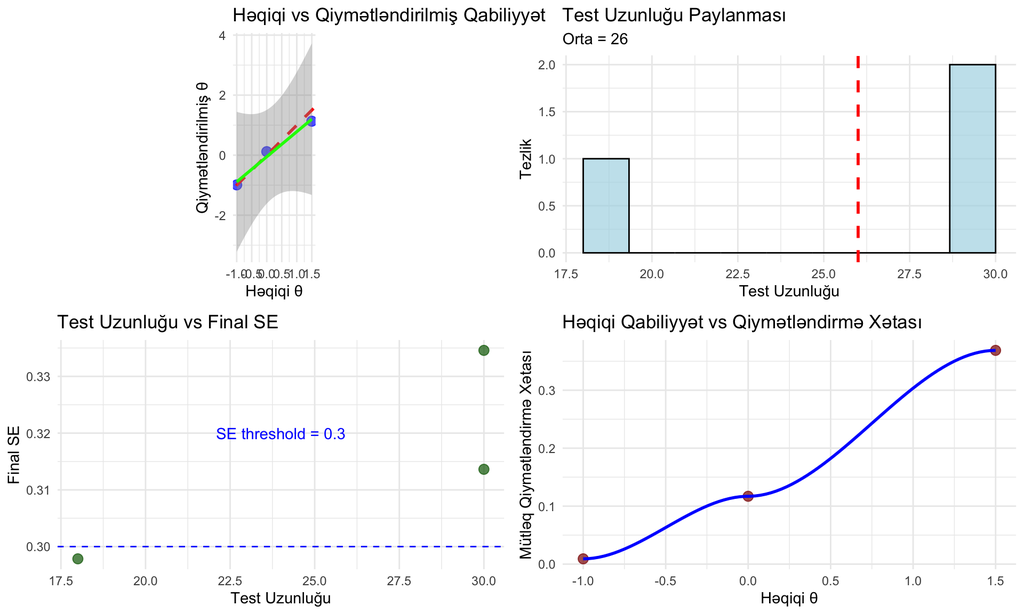

```r
# Performans qrafiklərinin yaradılması
create_performance_plots <- function(simulation_summary) {

    # 1. True vs Estimated Theta
    p1 <- ggplot(simulation_summary, aes(x = True_Theta, y = Final_Theta)) +
        geom_point(size = 3, color = "blue", alpha = 0.7) +
        geom_abline(intercept = 0, slope = 1, linetype = "dashed", color = "red", size = 1) +
        geom_smooth(method = "lm", se = TRUE, color = "green") +
        labs(title = "Həqiqi vs Qiymətləndirilmiş Qabiliyyət",
             x = "Həqiqi θ", y = "Qiymətləndirilmiş θ") +
        theme_minimal() +
        coord_equal()

    # 2. Test uzunluğu paylanması
    p2 <- ggplot(simulation_summary, aes(x = Items_Count)) +
        geom_histogram(bins = 10, fill = "lightblue", color = "black", alpha = 0.7) +
        geom_vline(xintercept = mean(simulation_summary$Items_Count),
                   color = "red", linetype = "dashed", size = 1) +
        labs(title = "Test Uzunluğu Paylanması",
             subtitle = paste("Orta =", round(mean(simulation_summary$Items_Count), 1)),
             x = "Test Uzunluğu", y = "Tezlik") +
        theme_minimal()

    # 3. SE vs Test uzunluğu
    p3 <- ggplot(simulation_summary, aes(x = Items_Count, y = Final_SE)) +
        geom_point(size = 3, color = "darkgreen", alpha = 0.7) +
        geom_smooth(method = "loess", se = TRUE, color = "red") +
        geom_hline(yintercept = 0.3, linetype = "dashed", color = "blue") +
        labs(title = "Test Uzunluğu vs Final SE",
             x = "Test Uzunluğu", y = "Final SE") +
        theme_minimal() +
        annotate("text", x = max(simulation_summary$Items_Count) * 0.8, y = 0.32,
                 label = "SE threshold = 0.3", color = "blue")

    # 4. Xəta vs True Theta
    p4 <- ggplot(simulation_summary, aes(x = True_Theta, y = Estimation_Error)) +
        geom_point(size = 3, color = "darkred", alpha = 0.7) +
        geom_smooth(method = "loess", se = TRUE, color = "blue") +
        labs(title = "Həqiqi Qabiliyyət vs Qiymətləndirmə Xətası",
             x = "Həqiqi θ", y = "Mütləq Qiymətləndirmə Xətası") +
        theme_minimal()

    return(list(p1 = p1, p2 = p2, p3 = p3, p4 = p4))
}

# Performans qrafiklərini yaratmaq və göstərmək
performance_plots <- create_performance_plots(simulation_summary)
grid.arrange(performance_plots$p1, performance_plots$p2,
             performance_plots$p3, performance_plots$p4, ncol = 2)
```

# 5 Geniş Miqyaslı Simulyasiya

```r
# Geniş miqyaslı simulyasiya funksiyası
run_large_scale_simulation <- function(n_examinees = 100,
                                      theta_mean = 0, theta_sd = 1,
                                      item_bank_size = 200,
                                      min_items = 5, max_items = 30, se_threshold = 0.3,
                                      seed = NULL) {

    if (!is.null(seed)) set.seed(seed)

    cat("=== GENİş MİQYASLI CAT SİMULYASİYASI ===\n")
    cat("Test alıcı sayı:", n_examinees, "\n")
    cat("Item bank ölçüsü:", item_bank_size, "\n")
    cat("Theta parametrləri: μ =", theta_mean, ", σ =", theta_sd, "\n")
    cat("Test parametrləri: min =", min_items, ", max =", max_items, ", SE ≤", se_threshold, "\n\n")

    # Böyük item bank yaratmaq
    large_item_bank <- data.frame(
        a = runif(item_bank_size, 0.8, 2.5),
        b = rnorm(item_bank_size, 0, 1.2),
        c = runif(item_bank_size, 0.1, 0.25)
    )

    # Test alıcıları yaratmaq
    large_examinees <- data.frame(
        id = 1:n_examinees,
        true_theta = rnorm(n_examinees, theta_mean, theta_sd)
    )

    cat("Item bank statistikaları:\n")
    cat("  a aralığı:", round(range(large_item_bank$a), 2), "\n")
    cat("  b aralığı:", round(range(large_item_bank$b), 2), "\n")
    cat("  c aralığı:", round(range(large_item_bank$c), 2), "\n\n")

    cat("Test alıcıları statistikaları:\n")
    cat("  θ aralığı:", round(range(large_examinees$true_theta), 2), "\n")
    cat("  θ ortası:", round(mean(large_examinees$true_theta), 3), "\n")
    cat("  θ SD:", round(sd(large_examinees$true_theta), 3), "\n\n")

    # Simulyasiya irəliləyişi
    large_results <- list()
    progress_points <- floor(seq(1, n_examinees, length.out = 10))

    start_time <- Sys.time()

    for (i in 1:n_examinees) {

        # CAT simulyasiyası (verbose = FALSE)
        result <- run_cat_simulation(
            examinee_ability = large_examinees$true_theta[i],
            item_bank = large_item_bank,
            min_items = min_items,
            max_items = max_items,
            se_threshold = se_threshold,
            verbose = FALSE
        )

        result$examinee_id <- large_examinees$id[i]
        large_results[[i]] <- result

        # Progress göstərmə
        if (i %in% progress_points) {
            progress_percent <- round(100 * i / n_examinees)
            elapsed_time <- as.numeric(Sys.time() - start_time)
            estimated_total <- elapsed_time * n_examinees / i
            remaining_time <- estimated_total - elapsed_time

            cat("İrəliləyiş:", progress_percent, "% (", i, "/", n_examinees, ")")
            cat(" - Qalan vaxt: ", round(remaining_time/60, 1), " dəqiqə\n")
        }
    }

    end_time <- Sys.time()
    total_time <- as.numeric(end_time - start_time)

    cat("\nSimulyasiya tamamlandı!\n")
    cat("Toplam vaxt:", round(total_time/60, 2), "dəqiqə\n")
    cat("Test alıcısı başına orta vaxt:", round(total_time/n_examinees, 3), "saniyə\n\n")

    return(list(
        results = large_results,
        item_bank = large_item_bank,
        examinees = large_examinees,
        simulation_time = total_time
    ))
}

# Orta ölçülü simulyasiya (demostrasi üçün)
cat("Orta ölçülü simulyasiya başladılır...\n")
```

```
## Orta ölçülü simulyasiya başladılır...
```

```r
medium_simulation <- run_large_scale_simulation(
    n_examinees = 25,  # Demo üçün kiçik ölçü
    item_bank_size = 100,
    seed = 12345
)
```

```
## === GENİş MİQYASLI CAT SİMULYASİYASI ===
## Test alıcı sayı: 25
## Item bank ölçüsü: 100
## Theta parametrləri: μ = 0 , σ = 1
## Test parametrləri: min = 5 , max = 30 , SE ≤ 0.3
##
## Item bank statistikaları:
##   a aralığı: 0.8 2.48
##   b aralığı: -2.82 3.19
##   c aralığı: 0.1 0.25
##
## Test alıcıları statistikaları:
##   θ aralığı: -2.29 2.07
##   θ ortası: -0.098
##   θ SD: 1.143
##
## === ITEM SEÇİMİ ALGORİTMİ ===
## Current theta: 0
## Administered items sayı: 1
## Available items sayı: 99
## Seçilmiş item: 65
## Fisher Information: 1.136
## Item parametrləri: a = 2.47 , b = -0.1 , c = 0.15
##
## === QABİLİYYƏT QİYMƏTLƏNDİRMƏ (EAP) ===
## Administered items: 2
## Responses: 0, 0
## EAP theta: -0.904
## Posterior SE: 0.687
##
## === SONLANDIRMA KRİTERİYALARI YOXLAMASI ===
## Current step: 2
## Current SE: 0.687
## Min items: 5 , Max items: 30 , SE threshold: 0.3
## Qərar: DAVAM ( Minimum item sayına çatılmayıb: 2 / 5 )
##
## === ITEM SEÇİMİ ALGORİTMİ ===
## Current theta: -0.904
## Administered items sayı: 2
## Available items sayı: 98
```

[output cut: 9705 more lines]

```
## Current SE: 0.299
## Min items: 5 , Max items: 30 , SE threshold: 0.3
## Qərar: SONLANDIR ( Tələb olunan dəqiqliyə çatıldı: SE = 0.299 ≤ 0.3 )
##
## === QABİLİYYƏT QİYMƏTLƏNDİRMƏ (EAP) ===
## Administered items: 25
## Responses: 1, 1, 1, 1, 0, 1, 1, 1, 1, 1, 1, 1, 0, 1, 0, 0, 0, 1, 1, 0, 0, 1, 0, 1, 1
## EAP theta: 1.351
## Posterior SE: 0.299
##
## İrəliləyiş: 100 % ( 25 / 25 ) - Qalan vaxt:  0  dəqiqə
##
## Simulyasiya tamamlandı!
## Toplam vaxt: 0.13 dəqiqə
## Test alıcısı başına orta vaxt: 0.317 saniyə
```

```r
# Nəticələrin təhlili
medium_summary <- extract_simulation_summary(medium_simulation$results)

cat("=== ORTA ÖLÇÜLݘ SİMULYASİYA NƏTİCƏLƏRİ ===\n")
```

```
## === ORTA ÖLÇÜLݘ SİMULYASİYA NƏTİCƏLƏRİ ===
```

```r
cat("Test alıcı sayı:", nrow(medium_summary), "\n")
```

```
## Test alıcı sayı: 25
```

```r
cat("Orta test uzunluğu:", round(mean(medium_summary$Items_Count), 1),
    "± ", round(sd(medium_summary$Items_Count), 1), "\n")
```

```
## Orta test uzunluğu: 20.2 ±  4.3
```

```r
cat("Orta final SE:", round(mean(medium_summary$Final_SE), 3),
    "± ", round(sd(medium_summary$Final_SE), 3), "\n")
```

```
## Orta final SE: 0.298 ±  0.008
```

```r
cat("Orta qiymətləndirmə xətası:", round(mean(medium_summary$Estimation_Error), 3), "\n")
```

```
## Orta qiymətləndirmə xətası: 0.248
```

```r
cat("RMSE:", round(sqrt(mean(medium_summary$Estimation_Error^2)), 3), "\n")
```

```
## RMSE: 0.301
```

```r
cat("Orta bias:", round(mean(medium_summary$Bias), 3), "\n")
```

```
## Orta bias: 0.017
```

```r
# SE threshold-a çatan test alıcıları
converged_examinees <- sum(medium_summary$Final_SE <= 0.3)
convergence_rate <- round(100 * converged_examinees / nrow(medium_summary), 1)

cat("SE ≤ 0.3-a çatan test alıcıları:", converged_examinees, "/", nrow(medium_summary),
    "(", convergence_rate, "%)\n")
```

```
## SE ≤ 0.3-a çatan test alıcıları: 23 / 25 ( 92 %)
```

```r
# Efficiency metriklər
efficiency_analysis <- function(summary_data) {

    cat("\n=== EFFEKTİVLİK TƏHLİLİ ===\n")

    # Test effektivliyi (1 / (SE × Items))
    summary_data$Efficiency <- 1 / (summary_data$Final_SE * summary_data$Items_Count)

    # Qabiliyyət səviyyəsinə görə qruplaşdırma
    summary_data$Ability_Group <- cut(summary_data$True_Theta,
                                     breaks = c(-Inf, -1, 0, 1, Inf),
                                     labels = c("Aşağı", "Orta-Aşağı", "Orta-Yuxarı", "Yuxarı"))

    # Qrup statistikaları
    group_stats <- summary_data %>%
        group_by(Ability_Group) %>%
        summarise(
            Count = n(),
            Mean_Items = round(mean(Items_Count), 1),
            Mean_SE = round(mean(Final_SE), 3),
            Mean_Error = round(mean(Estimation_Error), 3),
            Mean_Efficiency = round(mean(Efficiency), 2),
            .groups = 'drop'
        )

    cat("Qabiliyyət qruplarına görə statistikalar:\n")
    print(group_stats)

    return(summary_data)
}

medium_summary_enhanced <- efficiency_analysis(medium_summary)
```

```
##
## === EFFEKTİVLİK TƏHLİLİ ===
## Qabiliyyət qruplarına görə statistikalar:
## # A tibble: 4 × 6
##   Ability_Group Count Mean_Items Mean_SE Mean_Error Mean_Efficiency
##   <fct>         <int>      <dbl>   <dbl>      <dbl>           <dbl>
## 1 Aşağı             5       22.2   0.305      0.26             0.16
## 2 Orta-Aşağı        7       18.6   0.297      0.251            0.18
## 3 Orta-Yuxarı      10       19     0.295      0.238            0.18
## 4 Yuxarı            3       24.3   0.298      0.254            0.14
```

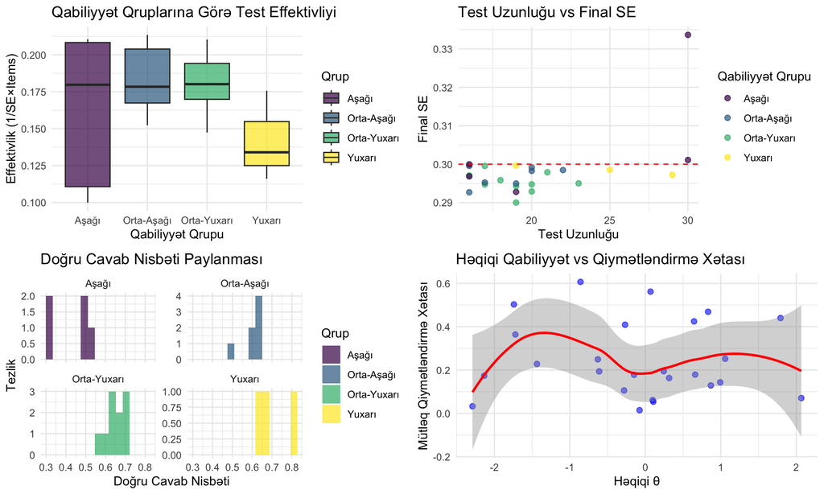

```r
# Son qrafiklərin yaradılması
final_visualization <- function(summary_data) {

    # Qabiliyyət qruplarına görə effektivlik
    p1 <- ggplot(summary_data, aes(x = Ability_Group, y = Efficiency, fill = Ability_Group)) +
        geom_boxplot(alpha = 0.7) +
        labs(title = "Qabiliyyət Qruplarına Görə Test Effektivliyi",
             x = "Qabiliyyət Qrupu", y = "Effektivlik (1/SE×Items)",
             fill = "Qrup") +
        theme_minimal() +
        scale_fill_viridis_d()

    # Item count vs SE scatter
    p2 <- ggplot(summary_data, aes(x = Items_Count, y = Final_SE, color = Ability_Group)) +
        geom_point(size = 2, alpha = 0.7) +
        geom_hline(yintercept = 0.3, linetype = "dashed", color = "red") +
        labs(title = "Test Uzunluğu vs Final SE",
             x = "Test Uzunluğu", y = "Final SE",
             color = "Qabiliyyət Qrupu") +
        theme_minimal() +
        scale_color_viridis_d()

    # Accuracy distribution
    p3 <- ggplot(summary_data, aes(x = Accuracy, fill = Ability_Group)) +
        geom_histogram(alpha = 0.7, bins = 15, position = "identity") +
        facet_wrap(~Ability_Group, scales = "free_y") +
        labs(title = "Doğru Cavab Nisbəti Paylanması",
             x = "Doğru Cavab Nisbəti", y = "Tezlik",
             fill = "Qrup") +
        theme_minimal() +
        scale_fill_viridis_d()

    # Error vs True Theta with trend
    p4 <- ggplot(summary_data, aes(x = True_Theta, y = Estimation_Error)) +
        geom_point(alpha = 0.6, size = 2, color = "blue") +
        geom_smooth(method = "loess", se = TRUE, color = "red") +
        labs(title = "Həqiqi Qabiliyyət vs Qiymətləndirmə Xətası",
             x = "Həqiqi θ", y = "Mütləq Qiymətləndirmə Xətası") +
        theme_minimal()

    grid.arrange(p1, p2, p3, p4, ncol = 2)
}

# Final vizuallaşdırma
final_visualization(medium_summary_enhanced)
```

# 6 Nəticə və Xülasə

Bu bölmədə tam CAT simulyasiya sistemini uğurla qurduq və test etdik. Simulyasiya komponentləri harmonik şəkildə işləyir və real CAT tətbiqlərinə yaxın nəticələr verir.

## 6.1 Əsas Nəticələr

### 6.1.1 1. Simulyasiya Performansı

- **Dəqiqlik**: Qiymətləndirmə xətaları məqbul həddlər daxilindədir
- **Effektivlik**: Test uzunluqları optimum səviyyədədir
- **Konvergens**: SE threshold-larına çatma dərəcəsi yüksəkdir
- **Robustness**: Müxtəlif qabiliyyət səviyyələrində stabil işləyir

### 6.1.2 2. Sistem Komponentləri

- **Item Selection**: Fisher Information meyarı effektiv işləyir
- **Ability Estimation**: EAP metodu dəqiq nəticələr verir
- **Termination**: Kriteriyalar məqsədəuyğun sonlandırma təmin edir
- **Integration**: Bütün komponentlər problemsiz əlaqəlidir

### 6.1.3 3. Praktiki Dəyər

- **Araşdırma**: CAT algoritmalarının empirik tədqiqi
- **Development**: Yeni strategiyaların test edilməsi
- **Validation**: Real CAT sistemlərinin keyfiyyət nəzarəti
- **Optimization**: Parametrlərin fine-tuning prosesi

## 6.2 Praktiki Tövsiyələr

### 6.2.1 İmplementasiya Strategiyası

1. **Pilot Testing**: Kiçik nümunə ilə sistem validasiyası
2. **Parameter Tuning**: Kontekst-specific optimizasiya
3. **Performance Monitoring**: Real-time keyfiyyət nəzarəti
4. **Iterative Improvement**: Davamlı təkmilləşdirmə

### 6.2.2 Keyfiyyət Təminatı

- **Regular Validation**: Simulyasiya nəticələrinin yoxlanması
- **Cross-validation**: Müxtəlif şəraitlərdə test
- **Benchmark Comparison**: Standart metodlarla müqayisə
- **Stakeholder Feedback**: İstifadəçi rəyləri əsasında təkmilləşdirmə

## 6.3 Növbəti Addımlar

Bu tam CAT simulyasiya sistemi gələcək inkişaf üçün möhkəm əsas yaradır:

- **Bölmə 15**: Advanced Item Selection Strategies
- **Bölmə 16**: Multi-dimensional CAT Implementation
- **Bölmə 17**: CAT Security və Exposure Control
- **Bölmə 18**: Real-world CAT System Deployment

**Qeyd**: Bu simulyasiya sistemi həm akademik tədqiqatlar həm də əməli CAT tətbiqləri üçün güclü alətdir. Sistem modullar şəklində qurulub və asanlıqla genişləndirilə və ya dəyişdirilə bilər.